# Lecture 8: Gram-Schmidt orthogonalization

## Modified Gram-Schmidt

The classical Gram-Schmidt process is numerically unstable, as will be seen in the next lecture. A mathematically equivalent formulation, which we call MGS, turns out to be a lot better.

In classical GS the key step is to project a new column of $A$ onto the orthogonal complement of the span of all the previous $q_j$s. We express this projection as $P_j=I - Q_jQ_j^*$, where $Q_j=\bigl[ q_1 \; q_2\; \cdots \; q_j\bigr]$. For example:

```matlab
[Qj,~] = qr(rand(6,3),0);   % get a random Q with 3 ON columns
Pj = eye(6) - Qj*Qj';
svd(Pj)       % all 1 or 0, as required for an orthogonal projector
```

```
ans =

    1.0000
    1.0000
    1.0000
    0.0000
    0.0000
    0.0000
```

It's intuitively clear that we get the same result by subtracting off projections onto each column, one at a time.

```matlab
Mj = eye(6) - Qj(:,1)*Qj(:,1)' - Qj(:,2)*Qj(:,2)' - Qj(:,3)*Qj(:,3)';
norm(Pj-Mj)
```

```
ans =

   1.2505e-16
```

We can also factor this into a product of orthogonal projectors:

```matlab
Gj = eye(6);
for k = 1:3
    Gj = Gj*(eye(6)-Qj(:,k)*Qj(:,k)');
end
norm(Gj-Pj)
```

```
ans =

   2.3849e-16
```

This works because the "cross-terms" you get in the products have inner products between different $q_k$ and thus are zero. In MGS, we apply each of these factors, as soon at it is found, to \emph{all} the columns of $A$ at once. By the time we are ready to choose a new column from $A$, it is already orthgonalized against the entire ON basis set found so far.

## Operation counts

It's standard in numerical analysis to compare the performance of algorithms by counting the number of floating point operations, or flops, that are performed as a function of the input size. By either form of QR factorization, the number of flops is $\sim 2mn^2$ in asymptotic notation. Let's see if we observe the implicit proportionality with respect to $n^2$.

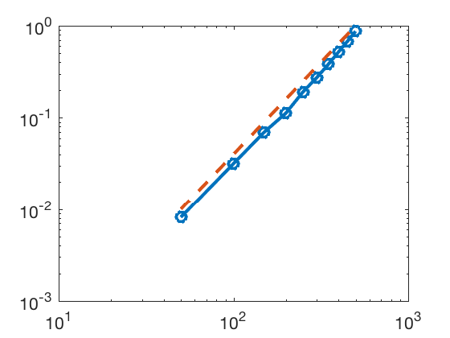

```matlab
n_ = 50:50:500;
time_ = [];
for k = 1:length(n_)
    n = n_(k);
    A = rand(1200,n);
    Q = zeros(1200,n);  R = zeros(600,600);

    tic
    R(1,1) = norm(A(:,1));
    Q(:,1) = A(:,1)/R(1,1);
    for j = 2:n
        R(1:j-1,j) = Q(:,1:j-1)'*A(:,j);
        v = A(:,j) - Q(:,1:j-1)*R(1:j-1,j);
        R(j,j) = norm(v);
        Q(:,j) = v/R(j,j);
    end
    time_(k) = toc;
end
loglog(n_,time_,'-o',n_,(n_/500).^2,'--')
axis tight, xlabel('n'), ylabel('elapsed time')
```

Flops aren't everything. On massively parallel computers, for example, the time needed for memory access and communication often competes with or dwarfs the floating point arithmetic.